# PHYS 210 Day 05 - Sep 17, 2025

Agenda:

1. No polling questions today. The Q&A questions tended to be about fiddly syntax things less suited to polling questions.
2. Preclass Q&A
3. Discussing Project 01
4. Worksheet 05

## Preclass 05 Q&A

**Topics:**

- More Linux command line
- Plotting with matplotlib

### Q: What does Linux do that modern interfaces can't? Is Linux something we must know in order to build programs?

For many (many) physics summer jobs or co-ops, you will be working in a Linux environment. At minimum we want you to have a starting point to build on. One of the strengths of Linux (or programming languages vs gui-based software) is the efficiency that you gain when doing a repetitive task.

**Example 1:** Physics 119 uses python instead of Excel, in part, because once you know how to build graphs in python it is only a few lines of code as opposed to multiple minutes of clicking on interface buttons to make a scatter plot, with error bars, and a best fit line.

**Example 2:** Me distributing group worksheets on CoCalc. I make 24 copies for each section, so need 48 copies and need to rename 48 files. That would take a very long time if I was using the graphical interface in CoCalc.

```
n=05
for i in {1..24}; do
    group_num=$(printf "%02d" $i)
    cp "Worksheet${n}.ipynb" "Worksheet${n}-Section101-Group${group_num}.ipynb"
    cp "Worksheet${n}.ipynb" "Worksheet${n}-Section102-Group${group_num}.ipynb"
done
```

## Reading topics for Plotting with matplotlib

```
import matplotlib.pyplot as plt
plt.plot([1, 2, 3, 4], [1, 4, 9, 16])
```

- Line and point styles
- Errorbars
- Saving figures to files (e.g., png)
- Multiple plots with `subplot()`
- Histograms and bar plots
- 2D Scatter plots (different point sizes & colours)

### Q. Can you review `plt.subplot()` and `plt.subplots()`?

### `plt.subplot()`

`plt.subplot()` lets you make composite figures with more than one plot set side-by-side or one above another. The parameters are three numbers (e.g., `plt.subplot(2,3,1)` ) where

- The first number (2) is how many rows of subplots there are,
- The second number(3) is how many columns there are
- And then the third number (1) is the index of the subplot you are currently plotting. This counting is like reading in English left to right and then proceeding downward: Bizarrely, the counting on this starts at 1, not 0.

For any one figure with subplots, the first two numbers should always be the same. Usage would look something like:

```
plt.subplot(2, 2, 1) # top-left
plt.plot(x1, y1)
plt.subplot(2, 2, 2) # top-right
plt.plot(x2,  y2)
plt.subplot(2, 2, 3) # bottom-left
plt.plot(x3, y3)
...
```

### `plt.subplots()`, which counts from 0 like most other things in python

```
# Before making any plots, indicate the arrangement of the canvas
fig, axes = plt.subplots(2, 3) # 2 rows, 3 columns

# Subplot on the first row and first column
axes[0, 0].plot(..)

# Subplot on the first row and second column
axes[0, 1].plot(..)
...
```

**Q.** How does it work when 3 lists/arrays are specified `plt.plot(a, a, b)`? https://matplotlib.org/stable/api/_as_gen/matplotlib.pyplot.plot.html

Let's start with what happens if you just use `plt.plot(b)`. When an argument is on its own, it gets interpretted as the `y` values and with `x` starting at 0, e.g., [0, 1, 2, 3]

```python
import numpy as np; import  matplotlib.pyplot as plt
a = np.linspace(2,5,5); plt.plot(a); plt.show()
```

[output not shown]

`plt.plot(a, a, b)`: First two arguments are taken as x and y values, so you get a vs a. The 3rd argument is by itself, so is interpreted as y values for a new graph.

```python
import numpy as np; import  matplotlib.pyplot as plt
a = np.linspace(1,4,5)
b = 3*a
plt.plot(a, a, b); plt.show()
```

[output not shown]

### Lots of people were struggling with the root finder question in Homework 4

Troubleshooting why you were not getting the expected output is an important and practiced skill. Lots of people were struggling with this. There is no "one true approach". Let's try an example

**Example:** `x0 = 0.000053` giving `n = 100` and `root = -99` instead of `root = 1`

- Re-read the question carefully to ensure that you undestand the expected output conditions. For example, should `n = 100` always give `root = -99` or do you still check convergence during that iteration?

And then use the debugger or print commands to try to understand where / why the issue is occurring...

Using the debugger or print commands:

- Start with a place where you have identified an output that is not what you expected (here we know that a specific `x0` value is giving the wrong value for `root`
- Double-check the values of `n` and `root` after the loop completes
- Double-check the values before going into the loop
- Next double-check the values for `n` and `root` at the end of the loop after the first couple of iterations and for the final couple of iterations. Are these values what you expect? Can you calculate what they should be by hand to confirm?

If none of this works, re-read the question again

# Let's discuss Project 01: Destructive collision(s)

**The goal of this project is to develop a research question, answered by a simulation involving one or more collisions and one or more objects that will be destroyed if they experience too large of a force during a collision. For example:**

> At which speeds and angles can I bounce a water balloon off the ground, such that it doesn’t explode and such that it hits a target on the wall?

We provide some starter code and further guidelines

## Timeline

[output not shown]

### Project submission deadlines

Submission deadlines indicate the dates at which a new round of grading will begin. Grading allocation is based on what has been submitted by the deadline. Late submissions can only be submitted to the next deadline.

|  | Oct 02 | Oct 09 | Oct 16 | Oct 23 | Oct 30 | Nov 06 | Nov 20 | Nov 27 | Dec 04 | Dec 10 | Dec 16 |
| --- | --- | --- | --- | --- | --- | --- | --- | --- | --- | --- | --- |
| **Submission Deadline** | #1 | #2 | #3 | #4 | #5 | #6 | #7 | #8 | #9 | #10 | #11 |
| **Recommended Submission** | Project 1 |  | Project 1 revision | Project 2 |  | Project 2 revision | Project 3 |  | Project 3 revision | Project 1 or 2 final revision | Project 3 final revision |

### I have posted

- Project 01 Report Template
- Project 01 Instructions & Assessment Guidelines - This includes we will be looking for in the report, what the expectations are to earn "Publish" and to earn distinctions
- An example general project with some annotations / feedback
- Homework 05 - Getting start on Project 01
- (Coming soon) A gallery of Project 01 posters from last year

### Distinction

Let's discuss the [Distinction Proposal Form](https://canvas.ubc.ca/courses/172613/assignments/2289455?module_item_id=8569048)

- Distinction submissions DO NOT count against your normal sumbission deadline count

# Questions about Project 01?

### Worksheet 05: We will be asking you about this

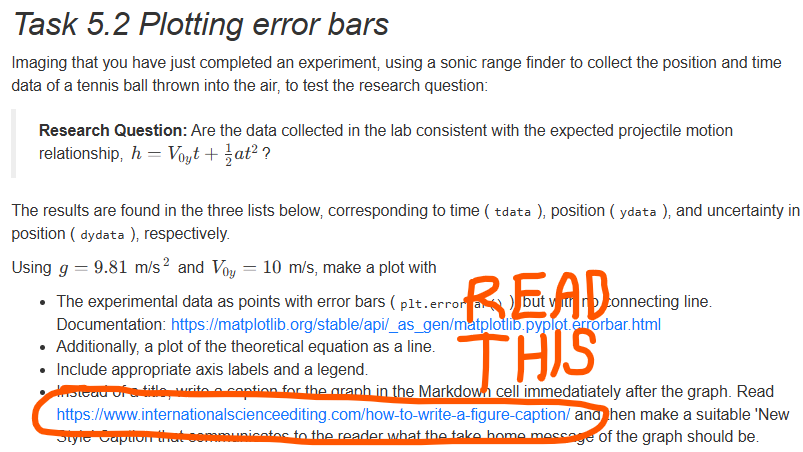

# The rest of today

- Group Worksheet 05
- Get started on Project 01 (via Homework 05)
- No Preclass 06 (the next one will be Preclass 09)

**Today:** Tables are grouped by similar PHYS 119 and 219 experience

- **Larger groups (3-4):** Work on CoCalc or get somebody in the group to project to TV at the end of your table
- **Pairs (2):** Work **closely** with a partner, ideally on one device